# Basics of working with randomness and probabilities

### 1.5 Histogram visualization

The `hist` function provides a variety of methods to visualize data in histogram formats.

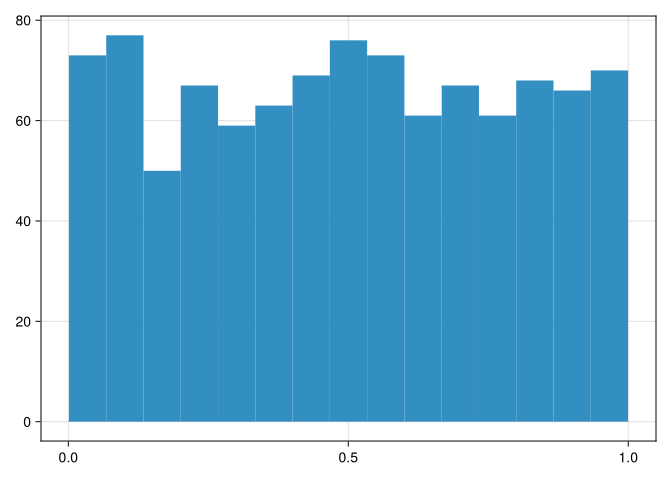

```julia
using CairoMakie
data = rand(Float64, 1000)
hist(data)
```

### 1.6 Exercises

#### 1.6.1 Visualizing uniform distributions

**Exercise 1**

Generate $N = 1000$ samples from each of the following distributions, and plot their histograms.

- $\mathcal{U}(-10, 10)$
- $\mathcal{U}(-10, \dots, 10)$

**Advanced**

- Write a function, `plot_uniform` that takes three integer (`Int`) arguments, `range_start`, `range_end`, and `n_samples`, and plots the results.
- Using this, produce plots of $N \in \{1 \times 10^4, 1 \times 10^5, \}$ etc., to see how the histograms appear more and more uniform as the sample size increases.

#### 1.6.2 Visualizing mathematical models by sampling points

**Exercise 2**

We previously used `range` to generate a regular grid of value for one set of coordinates:

```julia
α = 0.5
z_vals = range(0.0, 1/α; length = 400)
```

```
0.0:0.005012531328320802:2.0
```

The `range` range function returns a finite sequence of values, with different methods giving sequences of different data types, bounds, and intervals, depending on the input arguments. Here, `range(0.0, 1/α; length = 400)` is a method of the `range` function that returns a sequence of value between $0.0$ and $\frac{1}{\alpha}$

length = 400 represent the the number of samples/points in the function call range(…, length = 400) This forms a “grid” (a collection of regular systematic samples) on the x-axis. The y-values come from passing each y-value to the function to get the result. Instead of a systematic sample, we can randomly sample from the same range.

Instead of a systematic grid with `range`, generate a collection of $x$-coordinates of the same size by sampling independently from a uniform distribution over the same range and type using `rand`. Calculate the corresponding $y$-coordinates in the same way, by using `map` and the function. Visualize the results using `scatter`.

Here we both regularly (grid) and randomly sample 10 points from between 0.0 and 1/alpha:

julia> x_vals1 = collect(range(0.0, 1/α, length=10)) 10-element Vector{Float64}: 0.0 0.2222222222222222 0.4444444444444444 0.6666666666666666 0.8888888888888888 1.1111111111111112 1.3333333333333333 1.5555555555555556 1.7777777777777777 2.0

julia> x_vals2 = rand(0.0:0.01:1/α, 10) 10-element Vector{Float64}: 0.55 1.72 1.09 0.38 0.33 0.38 1.42 1.24 0.76 0.98 These all form one set of coordinates. The other, comes from applying the function to these:

y_vals1 = map(x -> ???, x_vals1) y_vals2 = map(x -> ???, x_vals2) Randomly sampling values from the model’s x value range as opposed to a regular grid makes sense when the range is huge (e.g. $-\infty$ to $\infty$), and we cannot possibly cover it all with a grid.

**Exercise 3**

- Simulate 1000 independent rolls of a single fair six-sided die by using `rand` to sample from an integer value in $\{1, 2, 3, 4, 5, 6\}$.
- Plot these

## 2 Simulating a Bernoulli trial with `rand`

We can use `rand()`, which returns a uniformly distributed real value in $[0, 1)$ to determine whether or not an event of given probability occurs or not in a particular sample (outcome, realization, draw, run, etc.) of a random system.

For an event with some given probability value, if the value returned by the `rand()` function is *less* than this value we consider the event to have occurred. By default then, if the result of `rand()` is greater than this value, the event has *not* occured.

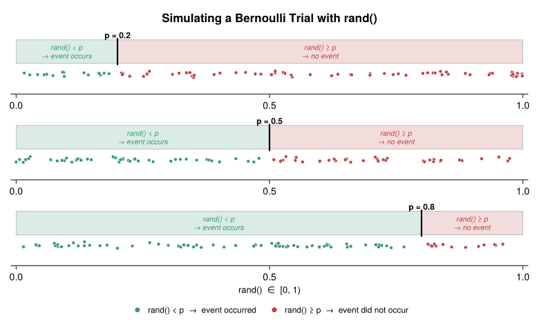

If we consider a uniform distribution on a subset of real number line between $0$ and $1$, and divide it at $p$ of various values, we can see the larger segment of the range assigned to one or the other outcome depending the parameter.

If we consider that `rand()` will return a sample anywhere in that range with equal probability, we can see how a larger $p$ means a value will fall in the part of the range that maps to the first outcome and vice versa.

if the result of a`rand()` is less than $p$, then we have simulated a sample in which the event has occurred, and conversely, if greater than or equal to $p$, to *not* have occured.

For example, consider the classical Bernoulli trial modeling an idealized fair coin toss, where there are two possible outcomes, “heads” or “tails”, with the probability of “heads” in any single realization being given by the model parameter $p=0.5$.

The short-hand Julia expression for this is:

```julia
rand() < 0.5 ? "heads" : "tails"
```

```
"heads"
```

Or, for a more readable, flexible, extensible, as well as maintanable, we define a named function that takes an argument which allows us to specify the probability parameter:

```julia
function bernoulli(p::Float64)::String
    if rand() < p
        "heads"
    else
        "tails"
    end
end
bernoulli(0.5)
```

```
"tails"
```

Back to top